# Sports Crime 2026 Report

Addina Rahaman and Alexie

2026-06-17 18:13:25.863909

# Replication

## Load Data

```r
offenses <- read_csv(here('offense_segment.csv'))
batches <- read_csv(here('nibrs_batch_header_1991_2024.csv')) %>%
  filter(grepl('200[0-5]', year))
```

## Organize and join

### Offenses Data

Filter and organize offenses within the programs of interest and only Group A offenses (assaults, vandalism)

```r
university_ori_lookup <- tribble(
  ~university, ~city_name, ~ori,
  'the university of akron', 'akron', 'OH0772800',
  'iowa state university', 'ames', 'IA0850100',
  'the university of michigan', 'ann arbor', 'MI8190300',
  'ohio university', 'athens', 'OH0050100',
  'the university of texas at austin', 'austin', 'TX2270500',
  'virginia polytechnic institute and state university', 'blacksburg', 'VA0600100',
  'boise state university', 'boise', 'ID0010100',
  'clemson university', 'clemson', 'SC0390600',
  'united states air force academy', 'colorado springs', 'CO0210100',
  'the university of south carolina', 'columbia', 'SC0400600',
  'the ohio state university', 'columbus', 'OH0252700',
  'the university of north texas', 'denton', 'TX0611100',
  'michigan state university', 'east lansing', 'MI3336400',
  'university of arkansas', 'fayetteville', 'AR0720400',
  'marshall university', 'huntington', 'WV0060200',
  'the university of iowa', 'iowa city', 'IA0520400',
  'arkansas state university', 'jonesboro', 'AR0160500',
  'western michigan university', 'kalamazoo', 'MI3949900',
  'the university of kansas', 'lawrence', 'KS0230100',
  'utah state university', 'logan', 'UT0031600',
  'texas tech university', 'lubbock', 'TX1520600',
  'west virginia university', 'morgantown', 'WV0310100',
  'the university of idaho', 'moscow', 'ID0290500',
  'eastern michigan university', 'mount pleasant', 'MI3759900',
  'middle tennessee state university', 'murfreesboro', 'TN0750100',
  'brigham young university', 'provo', 'UT0250600'
)

batches_filtered <- university_ori_lookup %>%
  left_join(batches, by=c('ori', 'city_name'))
```

```r
offenses_filtered <- batches_filtered %>%
  left_join(offenses) %>%
  drop_na(year)
# All the assault and vandalism cases
offenses_filtered <- offenses_filtered %>%
 filter(grepl('assault|vandalism', ucr_offense_code, ignore.case=TRUE))
```

### Game Schedule Data

Get the game schedules for 2000-2005

```r
game_schedule_raw <- c()
years <- 2000:2005

for (year in years) {
  i = year %% 2000 + 1
  game_schedule_raw[[i]] = espn_cfb_schedule(
    year = year
  )
}

names(game_schedule_raw) = c('2000', '2001', '2002', '2003', '2004', '2005')

game_schedule <- bind_rows(game_schedule_raw, .id='year')

game_schedule <- game_schedule %>%
  mutate(
    home_team_name = case_when(
      home_team_id == "2711" ~ "Broncos2", # Boise and western michigan have the same team name so im replacing western michigan with Broncos2
      TRUE ~ home_team_name
    )
  )
```

### Join and Aggregate

Join offenses data and schedule data and aggregate to get the number of offenses per agency day, and respective game/team information

```r
university_team_lookup <- tribble(
  ~university, ~team_name,
  'the university of akron', 'Zips',
  'iowa state university', 'Cyclones',
  'the university of michigan', 'Wolverines',
  'ohio university', 'Bobcats',
  'the university of texas at austin', 'Longhorns',
  'virginia polytechnic institute and state university', 'Hokies',
  'boise state university', 'Broncos',
  'clemson university', 'Tigers',
  'united states air force academy', 'Falcons',
  'the university of south carolina', 'Gamecocks',
  'the ohio state university', 'Buckeyes',
  'the university of north texas', 'Mean Green',
  'michigan state university', 'Spartans',
  'university of arkansas', 'Razorbacks',
  'marshall university', 'Thundering Herd',
  'the university of iowa', 'Hawkeyes',
  'arkansas state university', 'Red Wolves',
  'western michigan university', 'Broncos2',
  'the university of kansas', 'Jayhawks',
  'utah state university', 'Aggies',
  'texas tech university', 'Red Raiders',
  'west virginia university', 'Mountaineers',
  'the university of idaho', 'Vandals',
  'eastern michigan university', 'Eagles',
  'middle tennessee state university', 'Blue Raiders',
  'brigham young university', 'Cougars'
)

# create a column
offenses_filtered <- offenses_filtered %>%
  mutate(
    offense_type = case_when(
      (grepl('assault', ucr_offense_code)) ~ 'assault',
      (grepl('vandalism', ucr_offense_code)) ~ 'vandalism'
    )
  )

# create a column that classifies by no game, home game, and away game
agency_days <- offenses_filtered %>%
  filter((grepl('^200[0-5]-', incident_date))) %>%
  group_by(university, ori, incident_date, offense_type) %>%
  summarize(
    number_of_offenses=n()
  )
```

[output not shown]

```r
game_schedule_filtered <- game_schedule %>%
  select(year, matchup, season, game_date, home_team_name, away_team_name)

agency_days_and_programs <- agency_days %>%
  left_join(university_team_lookup)
agency_offenses_and_games <- agency_days_and_programs %>%
  left_join(game_schedule_filtered, by=c('incident_date' = 'game_date')) %>%
  mutate(
    game_type = case_when(
      (team_name == home_team_name) ~ 'home_game',
      (team_name == away_team_name) ~ 'away_game',
      TRUE ~ 'No game' # since we joined only by incident date and game date, it could be possible that neither home_team_name or away_team_name corresponds with team_name. in that case, the team was not involved at all
    )
  ) %>%
  group_by(ori, incident_date, offense_type, number_of_offenses) %>%
  summarize(
    actual_game_type = if (any(game_type == 'home_game')) { 'home_game' }
                      else if (any(game_type == 'away_game')) { 'away_game' }
                      else { 'no_game' }
  ) %>%
  rename(game_type=actual_game_type)
```

[output not shown]

## Plotting

### Appendix Table 1

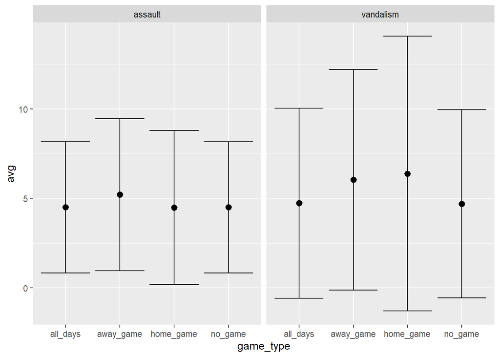

```r
# appendix 1
appendix_one_game <- agency_offenses_and_games %>%
  group_by(game_type, offense_type) %>%
  summarize(
    quantile_0.25 = quantile(number_of_offenses, 0.25, na.rm=TRUE),
    quantile_0.50 = quantile(number_of_offenses, 0.50, na.rm=TRUE),
    quantile_0.75 = quantile(number_of_offenses, 0.75, na.rm=TRUE),
    quantile_0.90 = quantile(number_of_offenses, 0.90, na.rm=TRUE),
    sd = sd(number_of_offenses),
    avg = mean(number_of_offenses),
    .groups = 'drop'
  )

appendix_one_all_day <- agency_offenses_and_games %>%
  group_by(offense_type) %>%
  summarize(
    quantile_0.25 = quantile(number_of_offenses, 0.25, na.rm=TRUE),
    quantile_0.50 = quantile(number_of_offenses, 0.50, na.rm=TRUE),
    quantile_0.75 = quantile(number_of_offenses, 0.75, na.rm=TRUE),
    quantile_0.90 = quantile(number_of_offenses, 0.90, na.rm=TRUE),
    sd = sd(number_of_offenses),
    avg = mean(number_of_offenses),
    .groups = 'drop'
  ) %>%
  mutate(game_type = 'all_days')

appendix_one <- bind_rows(appendix_one_game, appendix_one_all_day)

appendix_one %>%
  ggplot(aes(x=game_type, y=avg, ymin=avg-sd, ymax=avg+sd)) +
  geom_pointrange() +
  geom_errorbar() +
  facet_wrap(~ offense_type)
```

### Table 2

Plot the distribution of games and observed offenses by day of week

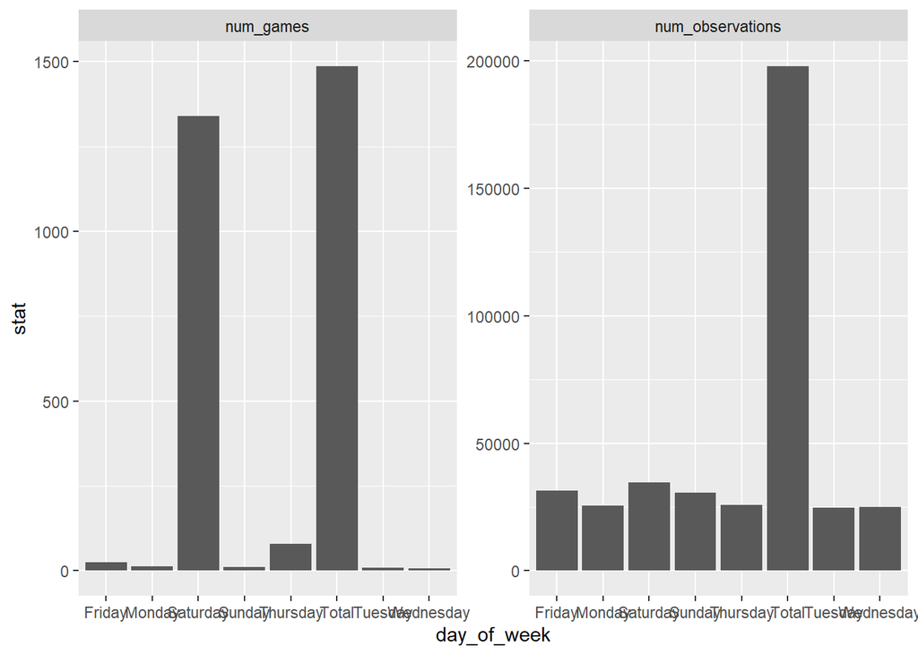

```r
# table 2 (distribution of games by day of week)

agency_offenses_and_games_by_day <- agency_offenses_and_games %>%
  mutate(day_of_week = weekdays(incident_date))

table2_obs <- agency_offenses_and_games_by_day  %>%
  group_by(day_of_week) %>%
  summarize(num_observations = sum(number_of_offenses))

table2_games <- game_schedule_filtered %>%
  filter(home_team_name %in% university_team_lookup$team_name | away_team_name %in% university_team_lookup$team_name) %>%
  mutate(day_of_week = weekdays(game_date)) %>%
  group_by(day_of_week) %>%
  summarize(num_games = n())

table2 <- inner_join(table2_games, table2_obs, by='day_of_week')

total <- table2 %>%
  summarize(
    total_games = sum(num_games),
    total_observations = sum(num_observations)
  ) %>%
  mutate(day_of_week='Total') %>%
  rename(num_games=total_games, num_observations=total_observations)

table2 <- bind_rows(table2, total)

table2 %>%
  pivot_longer(
    cols=starts_with('num_'),
    names_to='type',
    values_to='stat'
  ) %>%
  ggplot(aes(x=day_of_week, y=stat)) +
  geom_bar(stat = 'identity') +
  facet_wrap(~ type, scales='free')
```

### Descriptive Figure - Saturdays

Mean and standard error of number of offenses on Saturday (overall).

[output not shown]

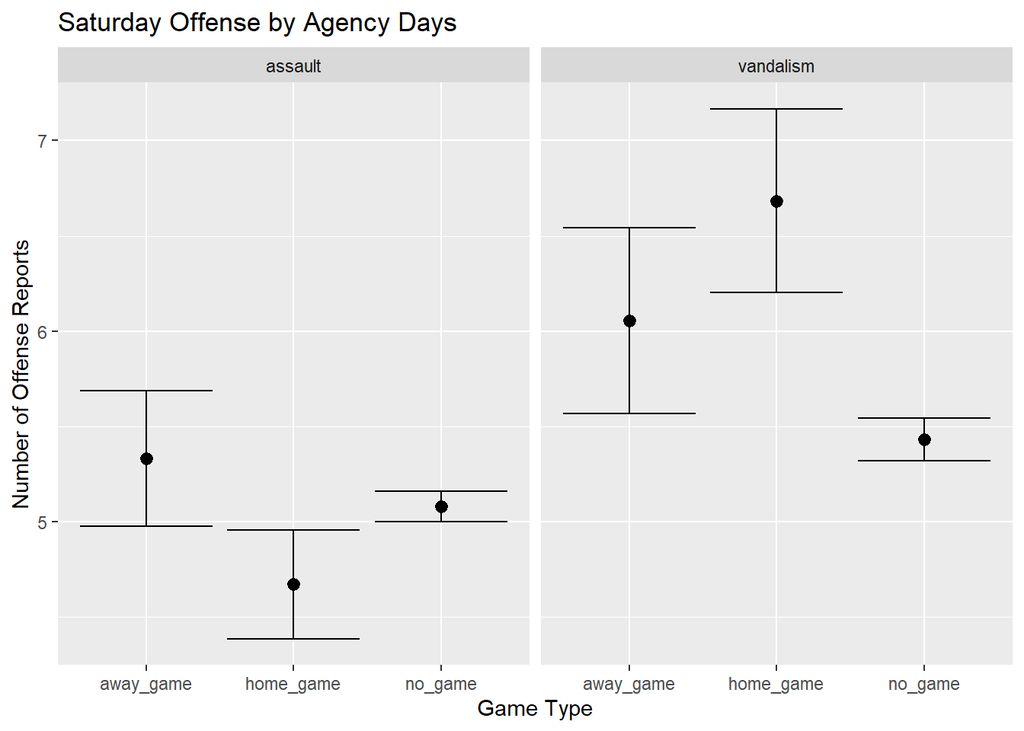

```r
# saturday plot
agency_offenses_and_games %>%
  mutate(day_of_week=weekdays(incident_date)) %>%
  filter(day_of_week=='Saturday') %>%
  group_by(game_type, offense_type) %>%
  summarize(
    count = n(),
    avg=mean(number_of_offenses),
    se=sd(number_of_offenses) / sqrt(count)
  ) %>%
  ggplot(aes(x = game_type, y=avg, ymin=avg-se, ymax=avg+se)) +
  geom_pointrange() +
  geom_errorbar() +
  labs(
    x = 'Game Type',
    y = 'Number of Offense Reports',
    title = 'Saturday Offense by Agency Days',
  ) +
  facet_wrap(~ offense_type)
```

### Descriptive Figure - Per team

Mean and standard error of offenses on Saturday (each university).

```
## `summarise()` has regrouped the output.
```

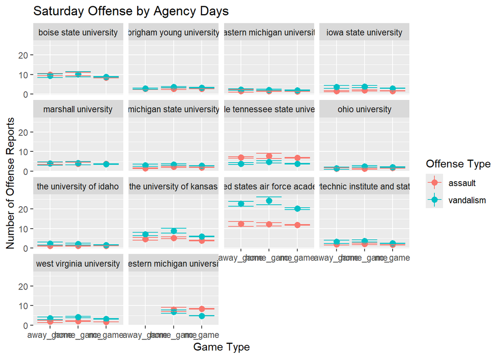

```r
# per team plots

# both offense types in one graph (cramped)
agency_offenses_and_games %>%
  mutate(day_of_week=weekdays(incident_date)) %>%
  filter(day_of_week=='Saturday') %>%
  left_join(university_ori_lookup) %>%
  group_by(university, game_type, offense_type) %>%
  summarize(
    count = n(),
    avg=mean(number_of_offenses),
    se=sd(number_of_offenses) / sqrt(count)
  ) %>%
  ggplot(aes(x = game_type, y=avg, ymin=avg-se, ymax=avg+se, color=offense_type)) +
  geom_pointrange() +
  geom_errorbar() +
  facet_wrap(~ university) +
  labs(
    x = 'Game Type',
    y = 'Number of Offense Reports',
    title = 'Saturday Offense by Agency Days',
    color = 'Offense Type'
  )
```

```
## `summarise()` has regrouped the output.
```

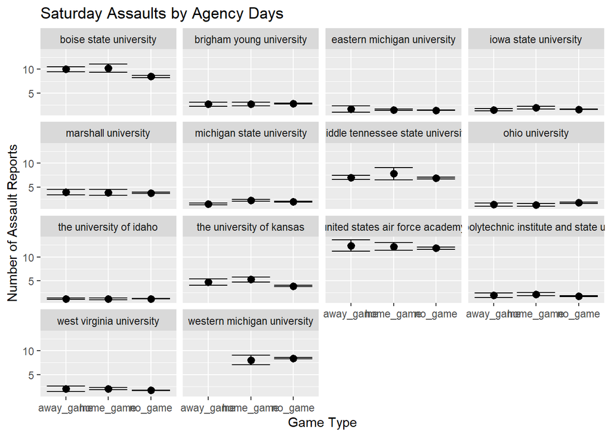

```r
# only assault reports per uni
agency_offenses_and_games %>%
  mutate(day_of_week=weekdays(incident_date)) %>%
  filter(day_of_week=='Saturday', offense_type=='assault') %>%
  left_join(university_ori_lookup) %>%
  group_by(university, game_type) %>%
  summarize(
    count = n(),
    avg=mean(number_of_offenses),
    se=sd(number_of_offenses) / sqrt(count)
  ) %>%
  ggplot(aes(x = game_type, y=avg, ymin=avg-se, ymax=avg+se)) +
  geom_pointrange() +
  geom_errorbar() +
  facet_wrap(~ university) +
  labs(
    x = 'Game Type',
    y = 'Number of Assault Reports',
    title = 'Saturday Assaults by Agency Days'
  )
```

```
## `summarise()` has regrouped the output.
```

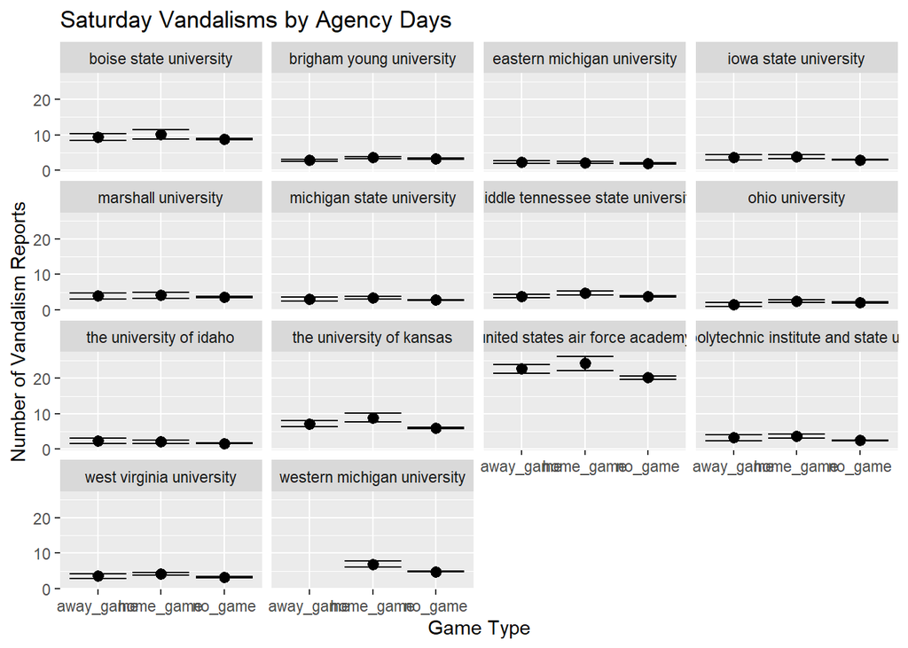

```r
# only vandalism reports per uni
agency_offenses_and_games %>%
  mutate(day_of_week=weekdays(incident_date)) %>%
  filter(day_of_week=='Saturday', offense_type=='vandalism') %>%
  left_join(university_ori_lookup) %>%
  group_by(university, game_type) %>%
  summarize(
    count = n(),
    avg=mean(number_of_offenses),
    se=sd(number_of_offenses) / sqrt(count)
  ) %>%
  ggplot(aes(x = game_type, y=avg, ymin=avg-se, ymax=avg+se)) +
  geom_pointrange() +
  geom_errorbar() +
  facet_wrap(~ university) +
  labs(
    x = 'Game Type',
    y = 'Number of Vandalism Reports',
    title = 'Saturday Vandalisms by Agency Days'
  )
```

## Regression - Table 3

### Re-organizing data

```r
# psuedo code: lm(daily_offense_count ~ home_game + away_game + agency_FE)
library(MASS)
# Hot Encode Game Type
factors <- model.matrix(~ game_type - 1, data = agency_offenses_and_games)
colnames(factors) <- sub("^game_type", "", colnames(factors))

# Horizontally stack data back to df
model_data <- bind_cols(agency_offenses_and_games, factors)

# Add features
model_data <- model_data %>%
mutate(
  day_of_week = wday(incident_date),
  month = month(incident_date),
  year = year(incident_date)
)
```

### Model Outputs

We did both linear regression models and negative binomial models. We ran each type of model on (1) both offense types combined (2) only assault offense types (3) only vandalism offense types. For each, we also computed the % increases compared to no game respective to the offense type and model type.

```r
# Overall Model - Linear Regression
mod <- lm(number_of_offenses ~ home_game + away_game + as.factor(ori) + as.factor(day_of_week) + as.factor(month) + as.factor(year),
data = model_data)

summary(mod)
```

```
##
## Call:
## lm(formula = number_of_offenses ~ home_game + away_game + as.factor(ori) +
##     as.factor(day_of_week) + as.factor(month) + as.factor(year),
##     data = model_data)
##
## Residuals:
##     Min      1Q  Median      3Q     Max
## -11.931  -1.471  -0.336   1.060  71.995
##
## Coefficients:
##                          Estimate Std. Error  t value Pr(>|t|)
## (Intercept)              12.92874    0.08597  150.388  < 2e-16 ***
## home_game                 0.45361    0.13630    3.328 0.000875 ***
## away_game                 0.25534    0.17265    1.479 0.139158
## as.factor(ori)IA0850100 -10.84398    0.07644 -141.859  < 2e-16 ***
## as.factor(ori)ID0010100  -5.86643    0.06700  -87.554  < 2e-16 ***
## as.factor(ori)ID0290500 -11.65599    0.09602 -121.389  < 2e-16 ***
## as.factor(ori)KS0230100  -8.76460    0.07579 -115.640  < 2e-16 ***
## as.factor(ori)MI3336400 -11.03447    0.07569 -145.781  < 2e-16 ***
## as.factor(ori)MI3759900 -11.40066    0.08162 -139.684  < 2e-16 ***
## as.factor(ori)MI3949900  -6.83943    0.06781 -100.862  < 2e-16 ***
## as.factor(ori)OH0050100 -11.55504    0.13401  -86.222  < 2e-16 ***
## as.factor(ori)TN0750100  -8.48589    0.06770 -125.348  < 2e-16 ***
## as.factor(ori)UT0250600 -10.26080    0.06916 -148.357  < 2e-16 ***
## as.factor(ori)VA0600100 -11.24474    0.07923 -141.927  < 2e-16 ***
## as.factor(ori)WV0060200  -9.57592    0.06935 -138.086  < 2e-16 ***
## as.factor(ori)WV0310100 -10.80968    0.07652 -141.275  < 2e-16 ***
## as.factor(day_of_week)2  -0.66839    0.05666  -11.797  < 2e-16 ***
## as.factor(day_of_week)3  -0.73817    0.05707  -12.933  < 2e-16 ***
## as.factor(day_of_week)4  -0.71716    0.05672  -12.644  < 2e-16 ***
## as.factor(day_of_week)5  -0.61059    0.05644  -10.819  < 2e-16 ***
## as.factor(day_of_week)6   0.15254    0.05555    2.746 0.006037 **
## as.factor(day_of_week)7   0.53880    0.05700    9.452  < 2e-16 ***
## as.factor(month)2        -0.12959    0.07630   -1.698 0.089438 .
## as.factor(month)3         0.38760    0.07444    5.207 1.93e-07 ***
## as.factor(month)4         0.60160    0.07399    8.130 4.40e-16 ***
## as.factor(month)5         0.69462    0.07423    9.357  < 2e-16 ***
## as.factor(month)6         0.71714    0.07481    9.586  < 2e-16 ***
## as.factor(month)7         0.90380    0.07384   12.239  < 2e-16 ***
## as.factor(month)8         0.61895    0.07405    8.358  < 2e-16 ***
## as.factor(month)9         0.66123    0.07549    8.759  < 2e-16 ***
## as.factor(month)10        0.67811    0.07488    9.056  < 2e-16 ***
## as.factor(month)11        0.38091    0.07549    5.046 4.53e-07 ***
## as.factor(month)12       -0.07610    0.07650   -0.995 0.319825
## as.factor(year)2001      -0.09660    0.05489   -1.760 0.078448 .
## as.factor(year)2002      -0.08470    0.05381   -1.574 0.115436
## as.factor(year)2003      -0.09984    0.05421   -1.842 0.065538 .
## as.factor(year)2004      -0.18462    0.05375   -3.435 0.000593 ***
## as.factor(year)2005      -0.18242    0.05361   -3.402 0.000668 ***
## ---
## Signif. codes:  0 '***' 0.001 '**' 0.01 '*' 0.05 '.' 0.1 ' ' 1
##
## Residual standard error: 3.133 on 42645 degrees of freedom
## Multiple R-squared:  0.5387, Adjusted R-squared:  0.5383
## F-statistic:  1346 on 37 and 42645 DF,  p-value: < 2.2e-16
```

```r
# Residuals:
#     Min      1Q  Median      3Q     Max
# -11.931  -1.471  -0.336   1.060  71.995

# Coefficients:
#                          Estimate Std. Error  t value Pr(>|t|)
# (Intercept)              12.92874    0.08597  150.388  < 2e-16 ***
# home_game                 0.45361    0.13630    3.328 0.000875 ***
# away_game                 0.25534    0.17265    1.479 0.139158
# as.factor(ori)IA0850100 -10.84398    0.07644 -141.859  < 2e-16 ***
# as.factor(ori)ID0010100  -5.86643    0.06700  -87.554  < 2e-16 ***
# as.factor(ori)ID0290500 -11.65599    0.09602 -121.389  < 2e-16 ***
# as.factor(ori)KS0230100  -8.76460    0.07579 -115.640  < 2e-16 ***
# as.factor(ori)MI3336400 -11.03447    0.07569 -145.781  < 2e-16 ***
# as.factor(ori)MI3759900 -11.40066    0.08162 -139.684  < 2e-16 ***
# as.factor(ori)MI3949900  -6.83943    0.06781 -100.862  < 2e-16 ***
# as.factor(ori)OH0050100 -11.55504    0.13401  -86.222  < 2e-16 ***
# as.factor(ori)TN0750100  -8.48589    0.06770 -125.348  < 2e-16 ***
# as.factor(ori)UT0250600 -10.26080    0.06916 -148.357  < 2e-16 ***
# as.factor(ori)VA0600100 -11.24474    0.07923 -141.927  < 2e-16 ***
# as.factor(ori)WV0060200  -9.57592    0.06935 -138.086  < 2e-16 ***
# as.factor(ori)WV0310100 -10.80968    0.07652 -141.275  < 2e-16 ***
# as.factor(day_of_week)2  -0.66839    0.05666  -11.797  < 2e-16 ***
# as.factor(day_of_week)3  -0.73817    0.05707  -12.933  < 2e-16 ***
# as.factor(day_of_week)4  -0.71716    0.05672  -12.644  < 2e-16 ***
# as.factor(day_of_week)5  -0.61059    0.05644  -10.819  < 2e-16 ***
# as.factor(day_of_week)6   0.15254    0.05555    2.746 0.006037 **
# as.factor(day_of_week)7   0.53880    0.05700    9.452  < 2e-16 ***
# as.factor(month)2        -0.12959    0.07630   -1.698 0.089438 .
# as.factor(month)3         0.38760    0.07444    5.207 1.93e-07 ***
# as.factor(month)4         0.60160    0.07399    8.130 4.40e-16 ***
# as.factor(month)5         0.69462    0.07423    9.357  < 2e-16 ***
# as.factor(month)6         0.71714    0.07481    9.586  < 2e-16 ***
# as.factor(month)7         0.90380    0.07384   12.239  < 2e-16 ***
# as.factor(month)8         0.61895    0.07405    8.358  < 2e-16 ***
# as.factor(month)9         0.66123    0.07549    8.759  < 2e-16 ***
# as.factor(month)10        0.67811    0.07488    9.056  < 2e-16 ***
# as.factor(month)11        0.38091    0.07549    5.046 4.53e-07 ***
# as.factor(month)12       -0.07610    0.07650   -0.995 0.319825
# as.factor(year)2001      -0.09660    0.05489   -1.760 0.078448 .
# as.factor(year)2002      -0.08470    0.05381   -1.574 0.115436
# as.factor(year)2003      -0.09984    0.05421   -1.842 0.065538 .
# as.factor(year)2004      -0.18462    0.05375   -3.435 0.000593 ***
# as.factor(year)2005      -0.18242    0.05361   -3.402 0.000668 ***
# ---
# Signif. codes:  0 '***' 0.001 '**' 0.01 '*' 0.05 '.' 0.1 ' ' 1

# Residual standard error: 3.133 on 42645 degrees of freedom
# Multiple R-squared:  0.5387,    Adjusted R-squared:  0.5383
# F-statistic:  1346 on 37 and 42645 DF,  p-value: < 2.2e-16


(exp(coef(mod)[2]) - 1) * 100
```

```
## home_game
##  57.39865
```

```r
# home_game
#  57.39865

# Overall Model - Negative Binomial Regression
mod2 <- glm.nb(number_of_offenses ~ home_game + away_game + as.factor(ori) + as.factor(day_of_week) + as.factor(month) + as.factor(year),
data = model_data)

summary(mod2)
```

```
##
## Call:
## glm.nb(formula = number_of_offenses ~ home_game + away_game +
##     as.factor(ori) + as.factor(day_of_week) + as.factor(month) +
##     as.factor(year), data = model_data, init.theta = 10.26283355,
##     link = log)
##
## Coefficients:
##                          Estimate Std. Error  z value Pr(>|z|)
## (Intercept)              2.541719   0.014979  169.680  < 2e-16 ***
## home_game                0.095007   0.024688    3.848 0.000119 ***
## away_game                0.038565   0.030628    1.259 0.207977
## as.factor(ori)IA0850100 -1.782776   0.015577 -114.453  < 2e-16 ***
## as.factor(ori)ID0010100 -0.598096   0.009732  -61.457  < 2e-16 ***
## as.factor(ori)ID0290500 -2.239320   0.024874  -90.026  < 2e-16 ***
## as.factor(ori)KS0230100 -1.122571   0.012639  -88.817  < 2e-16 ***
## as.factor(ori)MI3336400 -1.867027   0.015802 -118.149  < 2e-16 ***
## as.factor(ori)MI3759900 -2.085202   0.019032 -109.560  < 2e-16 ***
## as.factor(ori)MI3949900 -0.743169   0.010130  -73.360  < 2e-16 ***
## as.factor(ori)OH0050100 -2.182903   0.035455  -61.569  < 2e-16 ***
## as.factor(ori)TN0750100 -1.054498   0.010787  -97.756  < 2e-16 ***
## as.factor(ori)UT0250600 -1.550992   0.012631 -122.794  < 2e-16 ***
## as.factor(ori)VA0600100 -1.967833   0.017398 -113.107  < 2e-16 ***
## as.factor(ori)WV0060200 -1.328761   0.011904 -111.625  < 2e-16 ***
## as.factor(ori)WV0310100 -1.757706   0.015428 -113.928  < 2e-16 ***
## as.factor(day_of_week)2 -0.148590   0.010679  -13.914  < 2e-16 ***
## as.factor(day_of_week)3 -0.165973   0.010763  -15.421  < 2e-16 ***
## as.factor(day_of_week)4 -0.163948   0.010715  -15.301  < 2e-16 ***
## as.factor(day_of_week)5 -0.136754   0.010635  -12.859  < 2e-16 ***
## as.factor(day_of_week)6  0.015436   0.010263    1.504 0.132569
## as.factor(day_of_week)7  0.092602   0.010418    8.888  < 2e-16 ***
## as.factor(month)2       -0.026370   0.014824   -1.779 0.075269 .
## as.factor(month)3        0.092865   0.014165    6.556 5.52e-11 ***
## as.factor(month)4        0.133105   0.014069    9.461  < 2e-16 ***
## as.factor(month)5        0.140161   0.014048    9.977  < 2e-16 ***
## as.factor(month)6        0.138615   0.014123    9.815  < 2e-16 ***
## as.factor(month)7        0.178595   0.013876   12.871  < 2e-16 ***
## as.factor(month)8        0.123079   0.014052    8.759  < 2e-16 ***
## as.factor(month)9        0.145768   0.014338   10.166  < 2e-16 ***
## as.factor(month)10       0.149392   0.014190   10.528  < 2e-16 ***
```

[output cut: 8 more lines]

```
## Signif. codes:  0 '***' 0.001 '**' 0.01 '*' 0.05 '.' 0.1 ' ' 1
##
## (Dispersion parameter for Negative Binomial(10.2628) family taken to be 1)
##
##     Null deviance: 96362  on 42682  degrees of freedom
## Residual deviance: 36748  on 42645  degrees of freedom
## AIC: 181900
##
## Number of Fisher Scoring iterations: 1
##
##
##               Theta:  10.263
##           Std. Err.:  0.206
##
##  2 x log-likelihood:  -181822.043
```

```r
# Coefficients:
#                          Estimate Std. Error  z value Pr(>|z|)
# (Intercept)              2.541719   0.014979  169.680  < 2e-16 ***
# home_game                0.095007   0.024688    3.848 0.000119 ***
# away_game                0.038565   0.030628    1.259 0.207977
# as.factor(ori)IA0850100 -1.782776   0.015577 -114.453  < 2e-16 ***
# as.factor(ori)ID0010100 -0.598096   0.009732  -61.457  < 2e-16 ***
# as.factor(ori)ID0290500 -2.239320   0.024874  -90.026  < 2e-16 ***
# as.factor(ori)KS0230100 -1.122571   0.012639  -88.817  < 2e-16 ***
# as.factor(ori)MI3336400 -1.867027   0.015802 -118.149  < 2e-16 ***
# as.factor(ori)MI3759900 -2.085202   0.019032 -109.560  < 2e-16 ***
# as.factor(ori)MI3949900 -0.743169   0.010130  -73.360  < 2e-16 ***
# as.factor(ori)OH0050100 -2.182903   0.035455  -61.569  < 2e-16 ***
# as.factor(ori)TN0750100 -1.054498   0.010787  -97.756  < 2e-16 ***
# as.factor(ori)UT0250600 -1.550992   0.012631 -122.794  < 2e-16 ***
# as.factor(ori)VA0600100 -1.967833   0.017398 -113.107  < 2e-16 ***
# as.factor(ori)WV0060200 -1.328761   0.011904 -111.625  < 2e-16 ***
# as.factor(ori)WV0310100 -1.757706   0.015428 -113.928  < 2e-16 ***
# as.factor(day_of_week)2 -0.148590   0.010679  -13.914  < 2e-16 ***
# as.factor(day_of_week)3 -0.165973   0.010763  -15.421  < 2e-16 ***
# as.factor(day_of_week)4 -0.163948   0.010715  -15.301  < 2e-16 ***
# as.factor(day_of_week)5 -0.136754   0.010635  -12.859  < 2e-16 ***
# as.factor(day_of_week)6  0.015436   0.010263    1.504 0.132569
# as.factor(day_of_week)7  0.092602   0.010418    8.888  < 2e-16 ***
# as.factor(month)2       -0.026370   0.014824   -1.779 0.075269 .
# as.factor(month)3        0.092865   0.014165    6.556 5.52e-11 ***
# as.factor(month)4        0.133105   0.014069    9.461  < 2e-16 ***
# as.factor(month)5        0.140161   0.014048    9.977  < 2e-16 ***
# as.factor(month)6        0.138615   0.014123    9.815  < 2e-16 ***
# as.factor(month)7        0.178595   0.013876   12.871  < 2e-16 ***
# as.factor(month)8        0.123079   0.014052    8.759  < 2e-16 ***
# as.factor(month)9        0.145768   0.014338   10.166  < 2e-16 ***
# as.factor(month)10       0.149392   0.014190   10.528  < 2e-16 ***
# as.factor(month)11       0.092026   0.014402    6.390 1.66e-10 ***
# as.factor(month)12      -0.014071   0.014732   -0.955 0.339497
# as.factor(year)2001     -0.019395   0.010217   -1.898 0.057658 .
# as.factor(year)2002     -0.008020   0.010015   -0.801 0.423226
# as.factor(year)2003     -0.010210   0.010096   -1.011 0.311880
# as.factor(year)2004     -0.026491   0.010030   -2.641 0.008261 **
# as.factor(year)2005     -0.019553   0.010008   -1.954 0.050723 .
# ---
# Signif. codes:  0 '***' 0.001 '**' 0.01 '*' 0.05 '.' 0.1 ' ' 1

# (Dispersion parameter for Negative Binomial(10.2628) family taken to be 1)

#     Null deviance: 96362  on 42682  degrees of freedom
# Residual deviance: 36748  on 42645  degrees of freedom
# AIC: 181900

# Number of Fisher Scoring iterations: 1


#               Theta:  10.263
#           Std. Err.:  0.206

#  2 x log-likelihood:  -181822.043

( exp(coef(mod2)[2]) - 1 ) * 100
```

```
## home_game
##  9.966657
```

```r
# home_game
#  9.966657

# Filter Offense Type to Assault
model_data_assault <- model_data %>%
filter(offense_type == 'assault')

# Filter Offense Type to Vandalism
model_data_vandalism <- model_data %>%
filter(offense_type == 'vandalism')

# Linear Regression by Assault
mod_a <- lm(number_of_offenses ~ home_game + away_game + as.factor(ori) + as.factor(day_of_week) + as.factor(month) + as.factor(year),
data = model_data_assault)

summary(mod_a)
```

```
##
## Call:
## lm(formula = number_of_offenses ~ home_game + away_game + as.factor(ori) +
##     as.factor(day_of_week) + as.factor(month) + as.factor(year),
##     data = model_data_assault)
##
## Residuals:
##     Min      1Q  Median      3Q     Max
## -8.5186 -1.2404 -0.2230  0.9771 19.9941
##
## Coefficients:
##                         Estimate Std. Error t value Pr(>|t|)
## (Intercept)              9.67956    0.08979 107.808  < 2e-16 ***
## home_game               -0.04543    0.14262  -0.319 0.750086
## away_game                0.13552    0.18094   0.749 0.453893
## as.factor(ori)IA0850100 -8.10443    0.08607 -94.166  < 2e-16 ***
## as.factor(ori)ID0010100 -2.11973    0.06860 -30.901  < 2e-16 ***
## as.factor(ori)ID0290500 -8.40326    0.11448 -73.405  < 2e-16 ***
## as.factor(ori)KS0230100 -6.07651    0.07809 -77.811  < 2e-16 ***
## as.factor(ori)MI3336400 -7.90927    0.07998 -98.886  < 2e-16 ***
## as.factor(ori)MI3759900 -8.11230    0.08539 -94.999  < 2e-16 ***
## as.factor(ori)MI3949900 -1.85878    0.06920 -26.861  < 2e-16 ***
## as.factor(ori)OH0050100 -8.24931    0.14697 -56.130  < 2e-16 ***
## as.factor(ori)TN0750100 -3.94907    0.06869 -57.495  < 2e-16 ***
## as.factor(ori)UT0250600 -6.97765    0.07104 -98.224  < 2e-16 ***
## as.factor(ori)VA0600100 -8.05450    0.08450 -95.321  < 2e-16 ***
## as.factor(ori)WV0060200 -6.15318    0.07074 -86.986  < 2e-16 ***
## as.factor(ori)WV0310100 -8.02002    0.08454 -94.864  < 2e-16 ***
## as.factor(day_of_week)2 -0.93311    0.05994 -15.568  < 2e-16 ***
## as.factor(day_of_week)3 -0.83493    0.05995 -13.927  < 2e-16 ***
## as.factor(day_of_week)4 -0.82368    0.05972 -13.793  < 2e-16 ***
## as.factor(day_of_week)5 -0.68567    0.05938 -11.548  < 2e-16 ***
## as.factor(day_of_week)6 -0.41762    0.05844  -7.146 9.23e-13 ***
## as.factor(day_of_week)7  0.27968    0.05990   4.669 3.05e-06 ***
## as.factor(month)2       -0.16836    0.07977  -2.110 0.034828 *
## as.factor(month)3        0.25783    0.07820   3.297 0.000978 ***
## as.factor(month)4        0.46584    0.07798   5.974 2.35e-09 ***
## as.factor(month)5        0.56920    0.07802   7.295 3.09e-13 ***
## as.factor(month)6        0.47248    0.07871   6.002 1.98e-09 ***
## as.factor(month)7        0.65070    0.07786   8.357  < 2e-16 ***
## as.factor(month)8        0.46351    0.07768   5.967 2.46e-09 ***
## as.factor(month)9        0.59941    0.07950   7.539 4.93e-14 ***
## as.factor(month)10       0.40058    0.07888   5.078 3.85e-07 ***
## as.factor(month)11       0.07063    0.07977   0.885 0.375944
## as.factor(month)12      -0.16285    0.08062  -2.020 0.043409 *
## as.factor(year)2001      0.04331    0.05770   0.751 0.452926
## as.factor(year)2002      0.10553    0.05668   1.862 0.062630 .
## as.factor(year)2003     -0.12564    0.05729  -2.193 0.028312 *
## as.factor(year)2004      0.01200    0.05647   0.213 0.831698
## as.factor(year)2005      0.04724    0.05648   0.836 0.402951
## ---
## Signif. codes:  0 '***' 0.001 '**' 0.01 '*' 0.05 '.' 0.1 ' ' 1
##
## Residual standard error: 2.269 on 20143 degrees of freedom
## Multiple R-squared:  0.6204, Adjusted R-squared:  0.6197
## F-statistic: 889.9 on 37 and 20143 DF,  p-value: < 2.2e-16
```

```r
# Residuals:
#     Min      1Q  Median      3Q     Max
# -8.5186 -1.2404 -0.2230  0.9771 19.9941

# Coefficients:
#                         Estimate Std. Error t value Pr(>|t|)
# (Intercept)              9.67956    0.08979 107.808  < 2e-16 ***
# home_game               -0.04543    0.14262  -0.319 0.750086
# away_game                0.13552    0.18094   0.749 0.453893
# as.factor(ori)IA0850100 -8.10443    0.08607 -94.166  < 2e-16 ***
# as.factor(ori)ID0010100 -2.11973    0.06860 -30.901  < 2e-16 ***
# as.factor(ori)ID0290500 -8.40326    0.11448 -73.405  < 2e-16 ***
# as.factor(ori)KS0230100 -6.07651    0.07809 -77.811  < 2e-16 ***
# as.factor(ori)MI3336400 -7.90927    0.07998 -98.886  < 2e-16 ***
# as.factor(ori)MI3759900 -8.11230    0.08539 -94.999  < 2e-16 ***
# as.factor(ori)MI3949900 -1.85878    0.06920 -26.861  < 2e-16 ***
# as.factor(ori)OH0050100 -8.24931    0.14697 -56.130  < 2e-16 ***
# as.factor(ori)TN0750100 -3.94907    0.06869 -57.495  < 2e-16 ***
# as.factor(ori)UT0250600 -6.97765    0.07104 -98.224  < 2e-16 ***
# as.factor(ori)VA0600100 -8.05450    0.08450 -95.321  < 2e-16 ***
# as.factor(ori)WV0060200 -6.15318    0.07074 -86.986  < 2e-16 ***
# as.factor(ori)WV0310100 -8.02002    0.08454 -94.864  < 2e-16 ***
# as.factor(day_of_week)2 -0.93311    0.05994 -15.568  < 2e-16 ***
# as.factor(day_of_week)3 -0.83493    0.05995 -13.927  < 2e-16 ***
# as.factor(day_of_week)4 -0.82368    0.05972 -13.793  < 2e-16 ***
# as.factor(day_of_week)5 -0.68567    0.05938 -11.548  < 2e-16 ***
# as.factor(day_of_week)6 -0.41762    0.05844  -7.146 9.23e-13 ***
# as.factor(day_of_week)7  0.27968    0.05990   4.669 3.05e-06 ***
# as.factor(month)2       -0.16836    0.07977  -2.110 0.034828 *
# as.factor(month)3        0.25783    0.07820   3.297 0.000978 ***
# as.factor(month)4        0.46584    0.07798   5.974 2.35e-09 ***
# as.factor(month)5        0.56920    0.07802   7.295 3.09e-13 ***
# as.factor(month)6        0.47248    0.07871   6.002 1.98e-09 ***
# as.factor(month)7        0.65070    0.07786   8.357  < 2e-16 ***
# as.factor(month)8        0.46351    0.07768   5.967 2.46e-09 ***
# as.factor(month)9        0.59941    0.07950   7.539 4.93e-14 ***
# as.factor(month)10       0.40058    0.07888   5.078 3.85e-07 ***
# as.factor(month)11       0.07063    0.07977   0.885 0.375944
# as.factor(month)12      -0.16285    0.08062  -2.020 0.043409 *
# as.factor(year)2001      0.04331    0.05770   0.751 0.452926
# as.factor(year)2002      0.10553    0.05668   1.862 0.062630 .
# as.factor(year)2003     -0.12564    0.05729  -2.193 0.028312 *
# as.factor(year)2004      0.01200    0.05647   0.213 0.831698
# as.factor(year)2005      0.04724    0.05648   0.836 0.402951
# ---
# Signif. codes:  0 '***' 0.001 '**' 0.01 '*' 0.05 '.' 0.1 ' ' 1

# Residual standard error: 2.269 on 20143 degrees of freedom
# Multiple R-squared:  0.6204,    Adjusted R-squared:  0.6197
# F-statistic: 889.9 on 37 and 20143 DF,  p-value: < 2.2e-16

( exp(coef(mod_a)[2]) - 1 ) * 100
```

```
## home_game
## -4.441273
```

```r
# home_game
# -4.441273

# Negative Binomial Regression by Assault
mod_a2 <- glm.nb(number_of_offenses ~ home_game + away_game + as.factor(ori) + as.factor(day_of_week) + as.factor(month) + as.factor(year),
data = model_data_assault)

summary(mod_a2)
```

```
##
## Call:
## glm.nb(formula = number_of_offenses ~ home_game + away_game +
##     as.factor(ori) + as.factor(day_of_week) + as.factor(month) +
##     as.factor(year), data = model_data_assault, init.theta = 75.49893164,
##     link = log)
##
## Coefficients:
##                          Estimate Std. Error z value Pr(>|z|)
## (Intercept)              2.282613   0.017888 127.607  < 2e-16 ***
## home_game                0.013290   0.030918   0.430  0.66730
## away_game                0.024647   0.036838   0.669  0.50347
## as.factor(ori)IA0850100 -1.865694   0.026820 -69.563  < 2e-16 ***
## as.factor(ori)ID0010100 -0.251738   0.011057 -22.767  < 2e-16 ***
## as.factor(ori)ID0290500 -2.107846   0.043160 -48.838  < 2e-16 ***
## as.factor(ori)KS0230100 -1.017123   0.016538 -61.503  < 2e-16 ***
## as.factor(ori)MI3336400 -1.754868   0.023137 -75.846  < 2e-16 ***
## as.factor(ori)MI3759900 -1.910477   0.027325 -69.917  < 2e-16 ***
## as.factor(ori)MI3949900 -0.217696   0.011066 -19.672  < 2e-16 ***
## as.factor(ori)OH0050100 -1.954783   0.052461 -37.262  < 2e-16 ***
## as.factor(ori)TN0750100 -0.536035   0.011963 -44.808  < 2e-16 ***
## as.factor(ori)UT0250600 -1.320800   0.016346 -80.802  < 2e-16 ***
## as.factor(ori)VA0600100 -1.828375   0.025695 -71.158  < 2e-16 ***
## as.factor(ori)WV0060200 -1.038997   0.014618 -71.078  < 2e-16 ***
## as.factor(ori)WV0310100 -1.809071   0.025507 -70.926  < 2e-16 ***
## as.factor(day_of_week)2 -0.206000   0.012970 -15.883  < 2e-16 ***
## as.factor(day_of_week)3 -0.181655   0.012883 -14.101  < 2e-16 ***
## as.factor(day_of_week)4 -0.181326   0.012861 -14.099  < 2e-16 ***
## as.factor(day_of_week)5 -0.150107   0.012745 -11.778  < 2e-16 ***
## as.factor(day_of_week)6 -0.089824   0.012468  -7.205 5.82e-13 ***
## as.factor(day_of_week)7  0.054816   0.012398   4.421 9.81e-06 ***
## as.factor(month)2       -0.042115   0.017918  -2.350  0.01876 *
## as.factor(month)3        0.058524   0.017099   3.423  0.00062 ***
## as.factor(month)4        0.104214   0.016988   6.135 8.54e-10 ***
## as.factor(month)5        0.122678   0.016858   7.277 3.41e-13 ***
## as.factor(month)6        0.102446   0.017040   6.012 1.83e-09 ***
## as.factor(month)7        0.139607   0.016731   8.344  < 2e-16 ***
## as.factor(month)8        0.101819   0.016895   6.027 1.67e-09 ***
## as.factor(month)9        0.132149   0.017248   7.662 1.84e-14 ***
## as.factor(month)10       0.090118   0.017227   5.231 1.68e-07 ***
```

[output cut: 8 more lines]

```
## Signif. codes:  0 '***' 0.001 '**' 0.01 '*' 0.05 '.' 0.1 ' ' 1
##
## (Dispersion parameter for Negative Binomial(75.4989) family taken to be 1)
##
##     Null deviance: 52337  on 20180  degrees of freedom
## Residual deviance: 16606  on 20143  degrees of freedom
## AIC: 79767
##
## Number of Fisher Scoring iterations: 1
##
##
##               Theta:  75.5
##           Std. Err.:  10.7
##
##  2 x log-likelihood:  -79689.04
```

```r
# Coefficients:
#                          Estimate Std. Error z value Pr(>|z|)
# (Intercept)              2.282613   0.017888 127.607  < 2e-16 ***
# home_game                0.013290   0.030918   0.430  0.66730
# away_game                0.024647   0.036838   0.669  0.50347
# as.factor(ori)IA0850100 -1.865694   0.026820 -69.563  < 2e-16 ***
# as.factor(ori)ID0010100 -0.251738   0.011057 -22.767  < 2e-16 ***
# as.factor(ori)ID0290500 -2.107846   0.043160 -48.838  < 2e-16 ***
# as.factor(ori)KS0230100 -1.017123   0.016538 -61.503  < 2e-16 ***
# as.factor(ori)MI3336400 -1.754868   0.023137 -75.846  < 2e-16 ***
# as.factor(ori)MI3759900 -1.910477   0.027325 -69.917  < 2e-16 ***
# as.factor(ori)MI3949900 -0.217696   0.011066 -19.672  < 2e-16 ***
# as.factor(ori)OH0050100 -1.954783   0.052461 -37.262  < 2e-16 ***
# as.factor(ori)TN0750100 -0.536035   0.011963 -44.808  < 2e-16 ***
# as.factor(ori)UT0250600 -1.320800   0.016346 -80.802  < 2e-16 ***
# as.factor(ori)VA0600100 -1.828375   0.025695 -71.158  < 2e-16 ***
# as.factor(ori)WV0060200 -1.038997   0.014618 -71.078  < 2e-16 ***
# as.factor(ori)WV0310100 -1.809071   0.025507 -70.926  < 2e-16 ***
# as.factor(day_of_week)2 -0.206000   0.012970 -15.883  < 2e-16 ***
# as.factor(day_of_week)3 -0.181655   0.012883 -14.101  < 2e-16 ***
# as.factor(day_of_week)4 -0.181326   0.012861 -14.099  < 2e-16 ***
# as.factor(day_of_week)5 -0.150107   0.012745 -11.778  < 2e-16 ***
# as.factor(day_of_week)6 -0.089824   0.012468  -7.205 5.82e-13 ***
# as.factor(day_of_week)7  0.054816   0.012398   4.421 9.81e-06 ***
# as.factor(month)2       -0.042115   0.017918  -2.350  0.01876 *
# as.factor(month)3        0.058524   0.017099   3.423  0.00062 ***
# as.factor(month)4        0.104214   0.016988   6.135 8.54e-10 ***
# as.factor(month)5        0.122678   0.016858   7.277 3.41e-13 ***
# as.factor(month)6        0.102446   0.017040   6.012 1.83e-09 ***
# as.factor(month)7        0.139607   0.016731   8.344  < 2e-16 ***
# as.factor(month)8        0.101819   0.016895   6.027 1.67e-09 ***
# as.factor(month)9        0.132149   0.017248   7.662 1.84e-14 ***
# as.factor(month)10       0.090118   0.017227   5.231 1.68e-07 ***
# as.factor(month)11       0.015721   0.017637   0.891  0.37272
# as.factor(month)12      -0.037816   0.017860  -2.117  0.03423 *
# as.factor(year)2001      0.009747   0.012265   0.795  0.42677
# as.factor(year)2002      0.022988   0.012069   1.905  0.05681 .
# as.factor(year)2003     -0.027642   0.012328  -2.242  0.02494 *
# as.factor(year)2004      0.005099   0.012073   0.422  0.67281
# as.factor(year)2005      0.012574   0.012066   1.042  0.29739
# ---
# Signif. codes:  0 '***' 0.001 '**' 0.01 '*' 0.05 '.' 0.1 ' ' 1

# (Dispersion parameter for Negative Binomial(75.4989) family taken to be 1)

#     Null deviance: 52337  on 20180  degrees of freedom
# Residual deviance: 16606  on 20143  degrees of freedom
# AIC: 79767

# Number of Fisher Scoring iterations: 1


#               Theta:  75.5
#           Std. Err.:  10.7

#  2 x log-likelihood:  -79689.04

( exp(coef(mod_a2)[2]) - 1) * 100
```

```
## home_game
##  1.337914
```

```r
# home_game
#  1.337914

# Linear Regression by Vandalism
mod_v <- lm(number_of_offenses ~ home_game + away_game + as.factor(ori) + as.factor(day_of_week) + as.factor(month) + as.factor(year),
data = model_data_vandalism)

summary(mod_v)
```

```
##
## Call:
## lm(formula = number_of_offenses ~ home_game + away_game + as.factor(ori) +
##     as.factor(day_of_week) + as.factor(month) + as.factor(year),
##     data = model_data_vandalism)
##
## Residuals:
##     Min      1Q  Median      3Q     Max
## -14.554  -1.517  -0.354   1.065  68.139
##
## Coefficients:
##                           Estimate Std. Error  t value Pr(>|t|)
## (Intercept)              16.190292   0.124608  129.930  < 2e-16 ***
## home_game                 0.931266   0.197074    4.725 2.31e-06 ***
## away_game                 0.363135   0.249279    1.457  0.14520
## as.factor(ori)IA0850100 -13.884751   0.105599 -131.486  < 2e-16 ***
## as.factor(ori)ID0010100  -9.614388   0.098921  -97.193  < 2e-16 ***
## as.factor(ori)ID0290500 -15.033226   0.128120 -117.337  < 2e-16 ***
## as.factor(ori)KS0230100 -11.484507   0.111206 -103.272  < 2e-16 ***
## as.factor(ori)MI3336400 -14.223709   0.108715 -130.834  < 2e-16 ***
## as.factor(ori)MI3759900 -14.725179   0.118149 -124.633  < 2e-16 ***
## as.factor(ori)MI3949900 -11.865551   0.100443 -118.133  < 2e-16 ***
## as.factor(ori)OH0050100 -14.892507   0.186681  -79.775  < 2e-16 ***
## as.factor(ori)TN0750100 -13.107850   0.100911 -129.895  < 2e-16 ***
## as.factor(ori)UT0250600 -13.549547   0.101788 -133.116  < 2e-16 ***
## as.factor(ori)VA0600100 -14.510919   0.112984 -128.433  < 2e-16 ***
## as.factor(ori)WV0060200 -12.997664   0.102769 -126.475  < 2e-16 ***
## as.factor(ori)WV0310100 -13.832664   0.106737 -129.595  < 2e-16 ***
## as.factor(day_of_week)2  -0.460545   0.081138   -5.676 1.40e-08 ***
## as.factor(day_of_week)3  -0.683425   0.082249   -8.309  < 2e-16 ***
## as.factor(day_of_week)4  -0.648031   0.081565   -7.945 2.03e-15 ***
## as.factor(day_of_week)5  -0.558504   0.081216   -6.877 6.28e-12 ***
## as.factor(day_of_week)6   0.661499   0.079932    8.276  < 2e-16 ***
## as.factor(day_of_week)7   0.770982   0.082104    9.390  < 2e-16 ***
## as.factor(month)2        -0.071526   0.110423   -0.648  0.51716
## as.factor(month)3         0.520427   0.107257    4.852 1.23e-06 ***
## as.factor(month)4         0.748336   0.106312    7.039 1.99e-12 ***
## as.factor(month)5         0.831986   0.106909    7.782 7.43e-15 ***
## as.factor(month)6         0.963270   0.107638    8.949  < 2e-16 ***
## as.factor(month)7         1.156924   0.106044   10.910  < 2e-16 ***
## as.factor(month)8         0.795580   0.106845    7.446 9.96e-14 ***
## as.factor(month)9         0.743351   0.108530    6.849 7.61e-12 ***
## as.factor(month)10        0.954886   0.107615    8.873  < 2e-16 ***
## as.factor(month)11        0.671902   0.108197    6.210 5.39e-10 ***
## as.factor(month)12        0.009619   0.109903    0.088  0.93025
## as.factor(year)2001      -0.209304   0.079074   -2.647  0.00813 **
## as.factor(year)2002      -0.248309   0.077335   -3.211  0.00133 **
## as.factor(year)2003      -0.078812   0.077716   -1.014  0.31055
## as.factor(year)2004      -0.358148   0.077458   -4.624 3.79e-06 ***
## as.factor(year)2005      -0.376959   0.077077   -4.891 1.01e-06 ***
## ---
## Signif. codes:  0 '***' 0.001 '**' 0.01 '*' 0.05 '.' 0.1 ' ' 1
##
## Residual standard error: 3.271 on 22464 degrees of freedom
## Multiple R-squared:  0.6209, Adjusted R-squared:  0.6203
## F-statistic: 994.4 on 37 and 22464 DF,  p-value: < 2.2e-16
```

```r
# Residuals:
#     Min      1Q  Median      3Q     Max
# -14.554  -1.517  -0.354   1.065  68.139

# Coefficients:
#                           Estimate Std. Error  t value Pr(>|t|)
# (Intercept)              16.190292   0.124608  129.930  < 2e-16 ***
# home_game                 0.931266   0.197074    4.725 2.31e-06 ***
# away_game                 0.363135   0.249279    1.457  0.14520
# as.factor(ori)IA0850100 -13.884751   0.105599 -131.486  < 2e-16 ***
# as.factor(ori)ID0010100  -9.614388   0.098921  -97.193  < 2e-16 ***
# as.factor(ori)ID0290500 -15.033226   0.128120 -117.337  < 2e-16 ***
# as.factor(ori)KS0230100 -11.484507   0.111206 -103.272  < 2e-16 ***
# as.factor(ori)MI3336400 -14.223709   0.108715 -130.834  < 2e-16 ***
# as.factor(ori)MI3759900 -14.725179   0.118149 -124.633  < 2e-16 ***
# as.factor(ori)MI3949900 -11.865551   0.100443 -118.133  < 2e-16 ***
# as.factor(ori)OH0050100 -14.892507   0.186681  -79.775  < 2e-16 ***
# as.factor(ori)TN0750100 -13.107850   0.100911 -129.895  < 2e-16 ***
# as.factor(ori)UT0250600 -13.549547   0.101788 -133.116  < 2e-16 ***
# as.factor(ori)VA0600100 -14.510919   0.112984 -128.433  < 2e-16 ***
# as.factor(ori)WV0060200 -12.997664   0.102769 -126.475  < 2e-16 ***
# as.factor(ori)WV0310100 -13.832664   0.106737 -129.595  < 2e-16 ***
# as.factor(day_of_week)2  -0.460545   0.081138   -5.676 1.40e-08 ***
# as.factor(day_of_week)3  -0.683425   0.082249   -8.309  < 2e-16 ***
# as.factor(day_of_week)4  -0.648031   0.081565   -7.945 2.03e-15 ***
# as.factor(day_of_week)5  -0.558504   0.081216   -6.877 6.28e-12 ***
# as.factor(day_of_week)6   0.661499   0.079932    8.276  < 2e-16 ***
# as.factor(day_of_week)7   0.770982   0.082104    9.390  < 2e-16 ***
# as.factor(month)2        -0.071526   0.110423   -0.648  0.51716
# as.factor(month)3         0.520427   0.107257    4.852 1.23e-06 ***
# as.factor(month)4         0.748336   0.106312    7.039 1.99e-12 ***
# as.factor(month)5         0.831986   0.106909    7.782 7.43e-15 ***
# as.factor(month)6         0.963270   0.107638    8.949  < 2e-16 ***
# as.factor(month)7         1.156924   0.106044   10.910  < 2e-16 ***
# as.factor(month)8         0.795580   0.106845    7.446 9.96e-14 ***
# as.factor(month)9         0.743351   0.108530    6.849 7.61e-12 ***
# as.factor(month)10        0.954886   0.107615    8.873  < 2e-16 ***
# as.factor(month)11        0.671902   0.108197    6.210 5.39e-10 ***
# as.factor(month)12        0.009619   0.109903    0.088  0.93025
# as.factor(year)2001      -0.209304   0.079074   -2.647  0.00813 **
# as.factor(year)2002      -0.248309   0.077335   -3.211  0.00133 **
# as.factor(year)2003      -0.078812   0.077716   -1.014  0.31055
# as.factor(year)2004      -0.358148   0.077458   -4.624 3.79e-06 ***
# as.factor(year)2005      -0.376959   0.077077   -4.891 1.01e-06 ***
# ---
# Signif. codes:  0 '***' 0.001 '**' 0.01 '*' 0.05 '.' 0.1 ' ' 1

# Residual standard error: 3.271 on 22464 degrees of freedom
# Multiple R-squared:  0.6209,    Adjusted R-squared:  0.6203
# F-statistic: 994.4 on 37 and 22464 DF,  p-value: < 2.2e-16

( exp(coef(mod_v)[2]) - 1) * 100
```

```
## home_game
##   153.772
```

```r
# home_game
#   153.772

# Negative Binomial Regression by Vandalism
mod_v2 <- glm.nb(number_of_offenses ~ home_game + away_game + as.factor(ori) + as.factor(day_of_week) + as.factor(month) + as.factor(year),
data = model_data_vandalism)

summary(mod_v2)
```

```
##
## Call:
## glm.nb(formula = number_of_offenses ~ home_game + away_game +
##     as.factor(ori) + as.factor(day_of_week) + as.factor(month) +
##     as.factor(year), data = model_data_vandalism, init.theta = 10.50598044,
##     link = log)
##
## Coefficients:
##                          Estimate Std. Error  z value Pr(>|z|)
## (Intercept)              2.728989   0.020689  131.905  < 2e-16 ***
## home_game                0.151417   0.033005    4.588 4.48e-06 ***
## away_game                0.049468   0.041721    1.186 0.235749
## as.factor(ori)IA0850100 -1.841709   0.018757  -98.190  < 2e-16 ***
## as.factor(ori)ID0010100 -0.874000   0.013520  -64.644  < 2e-16 ***
## as.factor(ori)ID0290500 -2.398458   0.029803  -80.477  < 2e-16 ***
## as.factor(ori)KS0230100 -1.196994   0.016764  -71.405  < 2e-16 ***
## as.factor(ori)MI3336400 -1.967221   0.020299  -96.911  < 2e-16 ***
## as.factor(ori)MI3759900 -2.220720   0.024985  -88.882  < 2e-16 ***
## as.factor(ori)MI3949900 -1.268834   0.014971  -84.755  < 2e-16 ***
## as.factor(ori)OH0050100 -2.357093   0.045913  -51.338  < 2e-16 ***
## as.factor(ori)TN0750100 -1.580761   0.016305  -96.948  < 2e-16 ***
## as.factor(ori)UT0250600 -1.716640   0.017149 -100.101  < 2e-16 ***
## as.factor(ori)VA0600100 -2.091109   0.022315  -93.711  < 2e-16 ***
## as.factor(ori)WV0060200 -1.546121   0.016551  -93.413  < 2e-16 ***
## as.factor(ori)WV0310100 -1.811991   0.018822  -96.270  < 2e-16 ***
## as.factor(day_of_week)2 -0.108392   0.014691   -7.378 1.61e-13 ***
## as.factor(day_of_week)3 -0.166907   0.014987  -11.137  < 2e-16 ***
## as.factor(day_of_week)4 -0.162612   0.014887  -10.923  < 2e-16 ***
## as.factor(day_of_week)5 -0.136162   0.014777   -9.215  < 2e-16 ***
## as.factor(day_of_week)6  0.092779   0.014077    6.591 4.37e-11 ***
## as.factor(day_of_week)7  0.124321   0.014398    8.635  < 2e-16 ***
## as.factor(month)2       -0.007774   0.020720   -0.375 0.707508
## as.factor(month)3        0.125312   0.019691    6.364 1.97e-10 ***
## as.factor(month)4        0.165188   0.019514    8.465  < 2e-16 ***
## as.factor(month)5        0.160470   0.019566    8.201 2.38e-16 ***
## as.factor(month)6        0.180972   0.019579    9.243  < 2e-16 ***
## as.factor(month)7        0.224783   0.019212   11.700  < 2e-16 ***
## as.factor(month)8        0.156730   0.019553    8.016 1.09e-15 ***
## as.factor(month)9        0.170747   0.019916    8.573  < 2e-16 ***
## as.factor(month)10       0.211794   0.019606   10.803  < 2e-16 ***
```

[output cut: 8 more lines]

```
## Signif. codes:  0 '***' 0.001 '**' 0.01 '*' 0.05 '.' 0.1 ' ' 1
##
## (Dispersion parameter for Negative Binomial(10.506) family taken to be 1)
##
##     Null deviance: 58287  on 22501  degrees of freedom
## Residual deviance: 19798  on 22464  degrees of freedom
## AIC: 95992
##
## Number of Fisher Scoring iterations: 1
##
##
##               Theta:  10.506
##           Std. Err.:  0.299
##
##  2 x log-likelihood:  -95913.837
```

```r
# Coefficients:
#                          Estimate Std. Error  z value Pr(>|z|)
# (Intercept)              2.728989   0.020689  131.905  < 2e-16 ***
# home_game                0.151417   0.033005    4.588 4.48e-06 ***
# away_game                0.049468   0.041721    1.186 0.235749
# as.factor(ori)IA0850100 -1.841709   0.018757  -98.190  < 2e-16 ***
# as.factor(ori)ID0010100 -0.874000   0.013520  -64.644  < 2e-16 ***
# as.factor(ori)ID0290500 -2.398458   0.029803  -80.477  < 2e-16 ***
# as.factor(ori)KS0230100 -1.196994   0.016764  -71.405  < 2e-16 ***
# as.factor(ori)MI3336400 -1.967221   0.020299  -96.911  < 2e-16 ***
# as.factor(ori)MI3759900 -2.220720   0.024985  -88.882  < 2e-16 ***
# as.factor(ori)MI3949900 -1.268834   0.014971  -84.755  < 2e-16 ***
# as.factor(ori)OH0050100 -2.357093   0.045913  -51.338  < 2e-16 ***
# as.factor(ori)TN0750100 -1.580761   0.016305  -96.948  < 2e-16 ***
# as.factor(ori)UT0250600 -1.716640   0.017149 -100.101  < 2e-16 ***
# as.factor(ori)VA0600100 -2.091109   0.022315  -93.711  < 2e-16 ***
# as.factor(ori)WV0060200 -1.546121   0.016551  -93.413  < 2e-16 ***
# as.factor(ori)WV0310100 -1.811991   0.018822  -96.270  < 2e-16 ***
# as.factor(day_of_week)2 -0.108392   0.014691   -7.378 1.61e-13 ***
# as.factor(day_of_week)3 -0.166907   0.014987  -11.137  < 2e-16 ***
# as.factor(day_of_week)4 -0.162612   0.014887  -10.923  < 2e-16 ***
# as.factor(day_of_week)5 -0.136162   0.014777   -9.215  < 2e-16 ***
# as.factor(day_of_week)6  0.092779   0.014077    6.591 4.37e-11 ***
# as.factor(day_of_week)7  0.124321   0.014398    8.635  < 2e-16 ***
# as.factor(month)2       -0.007774   0.020720   -0.375 0.707508
# as.factor(month)3        0.125312   0.019691    6.364 1.97e-10 ***
# as.factor(month)4        0.165188   0.019514    8.465  < 2e-16 ***
# as.factor(month)5        0.160470   0.019566    8.201 2.38e-16 ***
# as.factor(month)6        0.180972   0.019579    9.243  < 2e-16 ***
# as.factor(month)7        0.224783   0.019212   11.700  < 2e-16 ***
# as.factor(month)8        0.156730   0.019553    8.016 1.09e-15 ***
# as.factor(month)9        0.170747   0.019916    8.573  < 2e-16 ***
# as.factor(month)10       0.211794   0.019606   10.803  < 2e-16 ***
# as.factor(month)11       0.160206   0.019826    8.081 6.45e-16 ***
# as.factor(month)12       0.003946   0.020485    0.193 0.847261
# as.factor(year)2001     -0.035548   0.014158   -2.511 0.012044 *
# as.factor(year)2002     -0.021499   0.013825   -1.555 0.119947
# as.factor(year)2003      0.014508   0.013826    1.049 0.294030
# as.factor(year)2004     -0.052860   0.013905   -3.802 0.000144 ***
# as.factor(year)2005     -0.042372   0.013842   -3.061 0.002205 **
# ---
# Signif. codes:  0 '***' 0.001 '**' 0.01 '*' 0.05 '.' 0.1 ' ' 1

# (Dispersion parameter for Negative Binomial(10.506) family taken to be 1)

#     Null deviance: 58287  on 22501  degrees of freedom
# Residual deviance: 19798  on 22464  degrees of freedom
# AIC: 95992

# Number of Fisher Scoring iterations: 1


#               Theta:  10.506
#           Std. Err.:  0.299

#  2 x log-likelihood:  -95913.837

( exp(coef(mod_v2)[2]) - 1 ) * 100
```

```
## home_game
##  16.34817
```

```r
# home_game
#  16.34817
```